# homework1

Shan

9/4/2020

```r
library(data.table)
library(tidyverse)
library(leaflet)
```

-Primary question: whether daliy concentrations of PM2.5 have decreased in California over the last 15 years(from 2004 to 2019)

-Step1: Summary: There are 19233 rows and 20 columns in 2004 dataset, no missing data, and the highest pm2.5 value is 251.00ug/m3 in the Yosimite on 07/18/2004, which is suspicious;There are 53328 rows and 20 columns in 2019 dataset, no missing data, and the highest pm2.5 value is 120.9ug/m3 in the Los Angeles on 10/11/2019, which is reasonable.

```r
pm_2004 = data.table::fread("/Users/haoyueshan/Desktop/PM566/week3/ad_viz_plotval_data_2004.csv")
pm_2019 = data.table::fread("/Users/haoyueshan/Desktop/PM566/week3/ad_viz_plotval_data_2019.csv")
dim(pm_2004)
```

```
## [1] 19233    20
```

```r
head(pm_2004)
```

```
##          Date Source  Site ID POC Daily Mean PM2.5 Concentration    UNITS
## 1: 01/01/2004    AQS 60010007   1                            8.9 ug/m3 LC
## 2: 01/02/2004    AQS 60010007   1                           12.2 ug/m3 LC
## 3: 01/03/2004    AQS 60010007   1                           16.5 ug/m3 LC
## 4: 01/04/2004    AQS 60010007   1                           19.5 ug/m3 LC
## 5: 01/05/2004    AQS 60010007   1                           11.5 ug/m3 LC
## 6: 01/06/2004    AQS 60010007   1                           32.5 ug/m3 LC
##    DAILY_AQI_VALUE Site Name DAILY_OBS_COUNT PERCENT_COMPLETE
## 1:              37 Livermore               1              100
## 2:              51 Livermore               1              100
## 3:              60 Livermore               1              100
## 4:              67 Livermore               1              100
## 5:              48 Livermore               1              100
## 6:              94 Livermore               1              100
##    AQS_PARAMETER_CODE                     AQS_PARAMETER_DESC CBSA_CODE
```

[output cut: 20 more lines]

```r
tail(pm_2004)
```

```
##          Date Source  Site ID POC Daily Mean PM2.5 Concentration    UNITS
## 1: 12/14/2004    AQS 61131003   1                             11 ug/m3 LC
## 2: 12/17/2004    AQS 61131003   1                             16 ug/m3 LC
## 3: 12/20/2004    AQS 61131003   1                             17 ug/m3 LC
## 4: 12/23/2004    AQS 61131003   1                              9 ug/m3 LC
## 5: 12/26/2004    AQS 61131003   1                             24 ug/m3 LC
## 6: 12/29/2004    AQS 61131003   1                              9 ug/m3 LC
##    DAILY_AQI_VALUE            Site Name DAILY_OBS_COUNT PERCENT_COMPLETE
## 1:              46 Woodland-Gibson Road               1              100
## 2:              59 Woodland-Gibson Road               1              100
## 3:              61 Woodland-Gibson Road               1              100
## 4:              38 Woodland-Gibson Road               1              100
## 5:              76 Woodland-Gibson Road               1              100
## 6:              38 Woodland-Gibson Road               1              100
##    AQS_PARAMETER_CODE       AQS_PARAMETER_DESC CBSA_CODE
```

[output cut: 20 more lines]

```r
str(pm_2004)
```

```
## Classes 'data.table' and 'data.frame':   19233 obs. of  20 variables:
##  $ Date                          : chr  "01/01/2004" "01/02/2004" "01/03/2004" "01/04/2004" ...
##  $ Source                        : chr  "AQS" "AQS" "AQS" "AQS" ...
##  $ Site ID                       : int  60010007 60010007 60010007 60010007 60010007 60010007 60010007 60010007 60010007 60010007 ...
##  $ POC                           : int  1 1 1 1 1 1 1 1 1 1 ...
##  $ Daily Mean PM2.5 Concentration: num  8.9 12.2 16.5 19.5 11.5 32.5 15.5 29.9 21 16.9 ...
##  $ UNITS                         : chr  "ug/m3 LC" "ug/m3 LC" "ug/m3 LC" "ug/m3 LC" ...
##  $ DAILY_AQI_VALUE               : int  37 51 60 67 48 94 58 88 70 61 ...
##  $ Site Name                     : chr  "Livermore" "Livermore" "Livermore" "Livermore" ...
##  $ DAILY_OBS_COUNT               : int  1 1 1 1 1 1 1 1 1 1 ...
##  $ PERCENT_COMPLETE              : num  100 100 100 100 100 100 100 100 100 100 ...
##  $ AQS_PARAMETER_CODE            : int  88101 88502 88502 88502 88502 88502 88502 88502 88502 88502 ...
##  $ AQS_PARAMETER_DESC            : chr  "PM2.5 - Local Conditions" "Acceptable PM2.5 AQI & Speciation Mass" "Acceptable PM2.5 AQI & Speciation Mass" "Acceptable PM2.5 AQI & Speciation Mass" ...
##  $ CBSA_CODE                     : int  41860 41860 41860 41860 41860 41860 41860 41860 41860 41860 ...
##  $ CBSA_NAME                     : chr  "San Francisco-Oakland-Hayward, CA" "San Francisco-Oakland-Hayward, CA" "San Francisco-Oakland-Hayward, CA" "San Francisco-Oakland-Hayward, CA" ...
##  $ STATE_CODE                    : int  6 6 6 6 6 6 6 6 6 6 ...
##  $ STATE                         : chr  "California" "California" "California" "California" ...
##  $ COUNTY_CODE                   : int  1 1 1 1 1 1 1 1 1 1 ...
##  $ COUNTY                        : chr  "Alameda" "Alameda" "Alameda" "Alameda" ...
##  $ SITE_LATITUDE                 : num  37.7 37.7 37.7 37.7 37.7 ...
##  $ SITE_LONGITUDE                : num  -122 -122 -122 -122 -122 ...
##  - attr(*, ".internal.selfref")=<externalptr>
```

```r
dim(pm_2019)
```

```
## [1] 53328    20
```

```r
head(pm_2019)
```

```
##          Date Source  Site ID POC Daily Mean PM2.5 Concentration    UNITS
## 1: 01/01/2019    AQS 60010007   3                            5.7 ug/m3 LC
## 2: 01/02/2019    AQS 60010007   3                           11.9 ug/m3 LC
## 3: 01/03/2019    AQS 60010007   3                           20.1 ug/m3 LC
## 4: 01/04/2019    AQS 60010007   3                           28.8 ug/m3 LC
## 5: 01/05/2019    AQS 60010007   3                           11.2 ug/m3 LC
## 6: 01/06/2019    AQS 60010007   3                            2.7 ug/m3 LC
##    DAILY_AQI_VALUE Site Name DAILY_OBS_COUNT PERCENT_COMPLETE
## 1:              24 Livermore               1              100
## 2:              50 Livermore               1              100
## 3:              68 Livermore               1              100
## 4:              86 Livermore               1              100
## 5:              47 Livermore               1              100
## 6:              11 Livermore               1              100
##    AQS_PARAMETER_CODE       AQS_PARAMETER_DESC CBSA_CODE
```

[output cut: 20 more lines]

```r
tail(pm_2019)
```

```
##          Date Source  Site ID POC Daily Mean PM2.5 Concentration    UNITS
## 1: 11/11/2019    AQS 61131003   1                           13.5 ug/m3 LC
## 2: 11/17/2019    AQS 61131003   1                           18.1 ug/m3 LC
## 3: 11/29/2019    AQS 61131003   1                           12.5 ug/m3 LC
## 4: 12/17/2019    AQS 61131003   1                           23.8 ug/m3 LC
## 5: 12/23/2019    AQS 61131003   1                            1.0 ug/m3 LC
## 6: 12/29/2019    AQS 61131003   1                            9.1 ug/m3 LC
##    DAILY_AQI_VALUE            Site Name DAILY_OBS_COUNT PERCENT_COMPLETE
## 1:              54 Woodland-Gibson Road               1              100
## 2:              64 Woodland-Gibson Road               1              100
## 3:              52 Woodland-Gibson Road               1              100
## 4:              76 Woodland-Gibson Road               1              100
## 5:               4 Woodland-Gibson Road               1              100
## 6:              38 Woodland-Gibson Road               1              100
##    AQS_PARAMETER_CODE       AQS_PARAMETER_DESC CBSA_CODE
```

[output cut: 20 more lines]

```r
str(pm_2019)
```

```
## Classes 'data.table' and 'data.frame':   53328 obs. of  20 variables:
##  $ Date                          : chr  "01/01/2019" "01/02/2019" "01/03/2019" "01/04/2019" ...
##  $ Source                        : chr  "AQS" "AQS" "AQS" "AQS" ...
##  $ Site ID                       : int  60010007 60010007 60010007 60010007 60010007 60010007 60010007 60010007 60010007 60010007 ...
##  $ POC                           : int  3 3 3 3 3 3 3 3 3 3 ...
##  $ Daily Mean PM2.5 Concentration: num  5.7 11.9 20.1 28.8 11.2 2.7 2.8 7 3.1 7.1 ...
##  $ UNITS                         : chr  "ug/m3 LC" "ug/m3 LC" "ug/m3 LC" "ug/m3 LC" ...
##  $ DAILY_AQI_VALUE               : int  24 50 68 86 47 11 12 29 13 30 ...
##  $ Site Name                     : chr  "Livermore" "Livermore" "Livermore" "Livermore" ...
##  $ DAILY_OBS_COUNT               : int  1 1 1 1 1 1 1 1 1 1 ...
##  $ PERCENT_COMPLETE              : num  100 100 100 100 100 100 100 100 100 100 ...
##  $ AQS_PARAMETER_CODE            : int  88101 88101 88101 88101 88101 88101 88101 88101 88101 88101 ...
##  $ AQS_PARAMETER_DESC            : chr  "PM2.5 - Local Conditions" "PM2.5 - Local Conditions" "PM2.5 - Local Conditions" "PM2.5 - Local Conditions" ...
##  $ CBSA_CODE                     : int  41860 41860 41860 41860 41860 41860 41860 41860 41860 41860 ...
##  $ CBSA_NAME                     : chr  "San Francisco-Oakland-Hayward, CA" "San Francisco-Oakland-Hayward, CA" "San Francisco-Oakland-Hayward, CA" "San Francisco-Oakland-Hayward, CA" ...
##  $ STATE_CODE                    : int  6 6 6 6 6 6 6 6 6 6 ...
##  $ STATE                         : chr  "California" "California" "California" "California" ...
##  $ COUNTY_CODE                   : int  1 1 1 1 1 1 1 1 1 1 ...
##  $ COUNTY                        : chr  "Alameda" "Alameda" "Alameda" "Alameda" ...
##  $ SITE_LATITUDE                 : num  37.7 37.7 37.7 37.7 37.7 ...
##  $ SITE_LONGITUDE                : num  -122 -122 -122 -122 -122 ...
##  - attr(*, ".internal.selfref")=<externalptr>
```

```r
summary(pm_2004$`Daily Mean PM2.5 Concentration`)
```

```
##    Min. 1st Qu.  Median    Mean 3rd Qu.    Max.
##   -0.10    6.00   10.10   13.13   16.30  251.00
```

```r
table(pm_2004$STATE)
```

```
##
## California
##      19233
```

```r
dim(pm_2004[is.na(`Daily Mean PM2.5 Concentration`)])[1]/dim(pm_2004)[1]
```

```
## [1] 0
```

```r
ss1 = pm_2004[`Daily Mean PM2.5 Concentration` == 251.00, .(`Date`, `Site Name`, `COUNTY`,`DAILY_AQI_VALUE`)]
table(ss1)
```

```
## , , COUNTY = Mariposa, DAILY_AQI_VALUE = 301
##
##             Site Name
## Date         Yosemite NP-Yosemite Village Vistor Center
##   07/18/2004                                          1
```

```r
summary(pm_2019$`Daily Mean PM2.5 Concentration`)
```

```
##    Min. 1st Qu.  Median    Mean 3rd Qu.    Max.
##  -2.200   4.000   6.500   7.744   9.900 120.900
```

```r
table(pm_2019$STATE)
```

```
##
## California
##      53328
```

```r
dim(pm_2019[is.na(`Daily Mean PM2.5 Concentration`)])[1]/dim(pm_2019)[1]
```

```
## [1] 0
```

```r
ss2 = pm_2019[`Daily Mean PM2.5 Concentration` == 120.90, .(`Date`, `Site Name`, `COUNTY`,`DAILY_AQI_VALUE`)]
table(ss2)
```

```
## , , COUNTY = Los Angeles, DAILY_AQI_VALUE = 185
##
##             Site Name
## Date         Reseda
##   10/11/2019      1
```

-Step2

```r
total = rbind(pm_2004,pm_2019)
total = rename(total, pm2.5 = `Daily Mean PM2.5 Concentration`, lat = `SITE_LATITUDE`, lon = `SITE_LONGITUDE`,  state = `STATE`, county = `COUNTY`, siteid = `Site ID`, sitename = `Site Name`)
head(total)
```

```
##          Date Source   siteid POC pm2.5    UNITS DAILY_AQI_VALUE  sitename
## 1: 01/01/2004    AQS 60010007   1   8.9 ug/m3 LC              37 Livermore
## 2: 01/02/2004    AQS 60010007   1  12.2 ug/m3 LC              51 Livermore
## 3: 01/03/2004    AQS 60010007   1  16.5 ug/m3 LC              60 Livermore
## 4: 01/04/2004    AQS 60010007   1  19.5 ug/m3 LC              67 Livermore
## 5: 01/05/2004    AQS 60010007   1  11.5 ug/m3 LC              48 Livermore
## 6: 01/06/2004    AQS 60010007   1  32.5 ug/m3 LC              94 Livermore
##    DAILY_OBS_COUNT PERCENT_COMPLETE AQS_PARAMETER_CODE
## 1:               1              100              88101
## 2:               1              100              88502
## 3:               1              100              88502
## 4:               1              100              88502
## 5:               1              100              88502
## 6:               1              100              88502
##                        AQS_PARAMETER_DESC CBSA_CODE
```

[output cut: 20 more lines]

```r
tail(total)
```

```
##          Date Source   siteid POC pm2.5    UNITS DAILY_AQI_VALUE
## 1: 11/11/2019    AQS 61131003   1  13.5 ug/m3 LC              54
## 2: 11/17/2019    AQS 61131003   1  18.1 ug/m3 LC              64
## 3: 11/29/2019    AQS 61131003   1  12.5 ug/m3 LC              52
## 4: 12/17/2019    AQS 61131003   1  23.8 ug/m3 LC              76
## 5: 12/23/2019    AQS 61131003   1   1.0 ug/m3 LC               4
## 6: 12/29/2019    AQS 61131003   1   9.1 ug/m3 LC              38
##                sitename DAILY_OBS_COUNT PERCENT_COMPLETE AQS_PARAMETER_CODE
## 1: Woodland-Gibson Road               1              100              88101
## 2: Woodland-Gibson Road               1              100              88101
## 3: Woodland-Gibson Road               1              100              88101
## 4: Woodland-Gibson Road               1              100              88101
## 5: Woodland-Gibson Road               1              100              88101
## 6: Woodland-Gibson Road               1              100              88101
##          AQS_PARAMETER_DESC CBSA_CODE                               CBSA_NAME
## 1: PM2.5 - Local Conditions     40900 Sacramento--Roseville--Arden-Arcade, CA
## 2: PM2.5 - Local Conditions     40900 Sacramento--Roseville--Arden-Arcade, CA
## 3: PM2.5 - Local Conditions     40900 Sacramento--Roseville--Arden-Arcade, CA
## 4: PM2.5 - Local Conditions     40900 Sacramento--Roseville--Arden-Arcade, CA
## 5: PM2.5 - Local Conditions     40900 Sacramento--Roseville--Arden-Arcade, CA
## 6: PM2.5 - Local Conditions     40900 Sacramento--Roseville--Arden-Arcade, CA
##    STATE_CODE      state COUNTY_CODE county      lat       lon
## 1:          6 California         113   Yolo 38.66121 -121.7327
## 2:          6 California         113   Yolo 38.66121 -121.7327
## 3:          6 California         113   Yolo 38.66121 -121.7327
## 4:          6 California         113   Yolo 38.66121 -121.7327
## 5:          6 California         113   Yolo 38.66121 -121.7327
## 6:          6 California         113   Yolo 38.66121 -121.7327
```

```r
library(date)
Date = total$Date
Date = as.date(Date)
temp = date.mdy(Date)$year
total = mutate(total, year = temp)
head(total)
```

```
##          Date Source   siteid POC pm2.5    UNITS DAILY_AQI_VALUE  sitename
## 1: 01/01/2004    AQS 60010007   1   8.9 ug/m3 LC              37 Livermore
## 2: 01/02/2004    AQS 60010007   1  12.2 ug/m3 LC              51 Livermore
## 3: 01/03/2004    AQS 60010007   1  16.5 ug/m3 LC              60 Livermore
## 4: 01/04/2004    AQS 60010007   1  19.5 ug/m3 LC              67 Livermore
## 5: 01/05/2004    AQS 60010007   1  11.5 ug/m3 LC              48 Livermore
## 6: 01/06/2004    AQS 60010007   1  32.5 ug/m3 LC              94 Livermore
##    DAILY_OBS_COUNT PERCENT_COMPLETE AQS_PARAMETER_CODE
## 1:               1              100              88101
## 2:               1              100              88502
## 3:               1              100              88502
## 4:               1              100              88502
## 5:               1              100              88502
## 6:               1              100              88502
##                        AQS_PARAMETER_DESC CBSA_CODE
```

[output cut: 20 more lines]

```r
tail(total)
```

```
##          Date Source   siteid POC pm2.5    UNITS DAILY_AQI_VALUE
## 1: 11/11/2019    AQS 61131003   1  13.5 ug/m3 LC              54
## 2: 11/17/2019    AQS 61131003   1  18.1 ug/m3 LC              64
## 3: 11/29/2019    AQS 61131003   1  12.5 ug/m3 LC              52
## 4: 12/17/2019    AQS 61131003   1  23.8 ug/m3 LC              76
## 5: 12/23/2019    AQS 61131003   1   1.0 ug/m3 LC               4
## 6: 12/29/2019    AQS 61131003   1   9.1 ug/m3 LC              38
##                sitename DAILY_OBS_COUNT PERCENT_COMPLETE AQS_PARAMETER_CODE
## 1: Woodland-Gibson Road               1              100              88101
## 2: Woodland-Gibson Road               1              100              88101
## 3: Woodland-Gibson Road               1              100              88101
## 4: Woodland-Gibson Road               1              100              88101
## 5: Woodland-Gibson Road               1              100              88101
## 6: Woodland-Gibson Road               1              100              88101
##          AQS_PARAMETER_DESC CBSA_CODE                               CBSA_NAME
## 1: PM2.5 - Local Conditions     40900 Sacramento--Roseville--Arden-Arcade, CA
## 2: PM2.5 - Local Conditions     40900 Sacramento--Roseville--Arden-Arcade, CA
## 3: PM2.5 - Local Conditions     40900 Sacramento--Roseville--Arden-Arcade, CA
## 4: PM2.5 - Local Conditions     40900 Sacramento--Roseville--Arden-Arcade, CA
## 5: PM2.5 - Local Conditions     40900 Sacramento--Roseville--Arden-Arcade, CA
## 6: PM2.5 - Local Conditions     40900 Sacramento--Roseville--Arden-Arcade, CA
##    STATE_CODE      state COUNTY_CODE county      lat       lon year
## 1:          6 California         113   Yolo 38.66121 -121.7327 2019
## 2:          6 California         113   Yolo 38.66121 -121.7327 2019
## 3:          6 California         113   Yolo 38.66121 -121.7327 2019
## 4:          6 California         113   Yolo 38.66121 -121.7327 2019
## 5:          6 California         113   Yolo 38.66121 -121.7327 2019
## 6:          6 California         113   Yolo 38.66121 -121.7327 2019
```

-Step3 The blue markers stand for sites in 2004, and the red markers stand for sites in 2019. Overall, there is more sites have been built in 2019 than 2004. For both year showed, the sites are more dense in the metropolis area, such as Sacramento, Oakland and Los Angeles. (I was trying use the codes at the bottom to drew both year in one map but it took forever and never show anything. Please let me know if there are anything I can do. )

```r
leaflet(pm_2004)%>%
  addProviderTiles('OpenStreetMap')%>%
  addCircles(lat=~`SITE_LATITUDE`, lng=~`SITE_LONGITUDE`, opacity = 1,fillOpacity = 1,radius = 100)
```

[interactive chart not shown]

```r
leaflet(pm_2019)%>%
  addProviderTiles('OpenStreetMap')%>%
  addCircles(lat=~`SITE_LATITUDE`, lng=~`SITE_LONGITUDE`, opacity = 1,fillOpacity = 1,radius = 100,color = "red")
```

[interactive chart not shown]

***(trying to add two layers of addCircles but is not working)

leaflet()%>% addProviderTiles(‘OpenStreetMap’)%>% addCircles(data = pm_2004, lat=~`SITE_LATITUDE`, lng=~`SITE_LONGITUDE`, opacity = 1,fillOpacity = 1,radius = 100,color = “blue”) addCircles(data = pm_2019, lat=~`SITE_LATITUDE`, lng=~`SITE_LONGITUDE`, opacity = 1,fillOpacity = 1,radius = 100,color = “red”)

***(try to drew the map in one but not work out)

getColor <- function(total){ sapply(total$year, function(year){ if (year==2004){ “green” } else { “red” } }) }

icons <- awesomeIcons( icon = ‘ios-close’, iconColor = ‘black’, library = ‘ion’, markerColor = getColor )

-Step4 There is no missing value in the combined data set. The negative value of pm2.5 is impossible so we remove them; the 251.0 is very suspicious but given the external sources i would keep this data point for further inspection. Overall, the max, mean and median value of pm2.5 are all lower in 2019 than 2004.

```r
dim(total[is.na(`pm2.5`)])[1]/dim(total)[1]
```

```
## [1] 0
```

```r
ss = total[`pm2.5` >= 120.9 , .(`Date`, `sitename`, `county`)]
table(ss)
```

```
## , , county = Los Angeles
##
##             sitename
## Date         Reseda Yosemite NP-Yosemite Village Vistor Center
##   07/18/2004      0                                          0
##   07/19/2004      0                                          0
##   07/20/2004      0                                          0
##   07/21/2004      0                                          0
##   10/11/2019      1                                          0
##
## , , county = Mariposa
##
##             sitename
## Date         Reseda Yosemite NP-Yosemite Village Vistor Center
##   07/18/2004      0                                          1
##   07/19/2004      0                                          1
##   07/20/2004      0                                          1
##   07/21/2004      0                                          1
##   10/11/2019      0                                          0
```

```r
summary(total$pm2.5)
```

```
##    Min. 1st Qu.  Median    Mean 3rd Qu.    Max.
##   -2.20    4.40    7.20    9.17   11.30  251.00
```

```r
total2 = total[pm2.5>=0]
head(total2)
```

```
##          Date Source   siteid POC pm2.5    UNITS DAILY_AQI_VALUE  sitename
## 1: 01/01/2004    AQS 60010007   1   8.9 ug/m3 LC              37 Livermore
## 2: 01/02/2004    AQS 60010007   1  12.2 ug/m3 LC              51 Livermore
## 3: 01/03/2004    AQS 60010007   1  16.5 ug/m3 LC              60 Livermore
## 4: 01/04/2004    AQS 60010007   1  19.5 ug/m3 LC              67 Livermore
## 5: 01/05/2004    AQS 60010007   1  11.5 ug/m3 LC              48 Livermore
## 6: 01/06/2004    AQS 60010007   1  32.5 ug/m3 LC              94 Livermore
##    DAILY_OBS_COUNT PERCENT_COMPLETE AQS_PARAMETER_CODE
## 1:               1              100              88101
## 2:               1              100              88502
## 3:               1              100              88502
## 4:               1              100              88502
## 5:               1              100              88502
## 6:               1              100              88502
##                        AQS_PARAMETER_DESC CBSA_CODE
```

[output cut: 20 more lines]

```r
tail(total2)
```

```
##          Date Source   siteid POC pm2.5    UNITS DAILY_AQI_VALUE
## 1: 11/11/2019    AQS 61131003   1  13.5 ug/m3 LC              54
## 2: 11/17/2019    AQS 61131003   1  18.1 ug/m3 LC              64
## 3: 11/29/2019    AQS 61131003   1  12.5 ug/m3 LC              52
## 4: 12/17/2019    AQS 61131003   1  23.8 ug/m3 LC              76
## 5: 12/23/2019    AQS 61131003   1   1.0 ug/m3 LC               4
## 6: 12/29/2019    AQS 61131003   1   9.1 ug/m3 LC              38
##                sitename DAILY_OBS_COUNT PERCENT_COMPLETE AQS_PARAMETER_CODE
## 1: Woodland-Gibson Road               1              100              88101
## 2: Woodland-Gibson Road               1              100              88101
## 3: Woodland-Gibson Road               1              100              88101
## 4: Woodland-Gibson Road               1              100              88101
## 5: Woodland-Gibson Road               1              100              88101
## 6: Woodland-Gibson Road               1              100              88101
##          AQS_PARAMETER_DESC CBSA_CODE                               CBSA_NAME
## 1: PM2.5 - Local Conditions     40900 Sacramento--Roseville--Arden-Arcade, CA
## 2: PM2.5 - Local Conditions     40900 Sacramento--Roseville--Arden-Arcade, CA
## 3: PM2.5 - Local Conditions     40900 Sacramento--Roseville--Arden-Arcade, CA
## 4: PM2.5 - Local Conditions     40900 Sacramento--Roseville--Arden-Arcade, CA
## 5: PM2.5 - Local Conditions     40900 Sacramento--Roseville--Arden-Arcade, CA
## 6: PM2.5 - Local Conditions     40900 Sacramento--Roseville--Arden-Arcade, CA
##    STATE_CODE      state COUNTY_CODE county      lat       lon year
## 1:          6 California         113   Yolo 38.66121 -121.7327 2019
## 2:          6 California         113   Yolo 38.66121 -121.7327 2019
## 3:          6 California         113   Yolo 38.66121 -121.7327 2019
## 4:          6 California         113   Yolo 38.66121 -121.7327 2019
## 5:          6 California         113   Yolo 38.66121 -121.7327 2019
## 6:          6 California         113   Yolo 38.66121 -121.7327 2019
```

```r
summary(total2$pm2.5)
```

```
##    Min. 1st Qu.  Median    Mean 3rd Qu.    Max.
##   0.000   4.400   7.300   9.211  11.300 251.000
```

```r
summary(pm_2004$`Daily Mean PM2.5 Concentration`)
```

```
##    Min. 1st Qu.  Median    Mean 3rd Qu.    Max.
##   -0.10    6.00   10.10   13.13   16.30  251.00
```

```r
summary(pm_2019$`Daily Mean PM2.5 Concentration`)
```

```
##    Min. 1st Qu.  Median    Mean 3rd Qu.    Max.
##  -2.200   4.000   6.500   7.744   9.900 120.900
```

-Step5 -Primary question: whether daily concentrations of PM2.5 have decreased in California over the last 15 years(from 2004 to 2019) -state(state) -county(county) -site in Los Angeles

```r
summary(total2$pm2.5)
```

```
##    Min. 1st Qu.  Median    Mean 3rd Qu.    Max.
##   0.000   4.400   7.300   9.211  11.300 251.000
```

```r
siteinLA_2004 = filter(total2, county =="Los Angeles", year =="2004")
siteinLA_2019 = filter(total2, county =="Los Angeles", year =="2019")
summary(siteinLA_2004$pm2.5)
```

```
##    Min. 1st Qu.  Median    Mean 3rd Qu.    Max.
##     0.1    10.5    14.7    17.1    20.4    75.6
```

```r
summary(siteinLA_2019$pm2.5)
```

```
##    Min. 1st Qu.  Median    Mean 3rd Qu.    Max.
##    0.00    6.40    9.50   10.17   12.90  120.90
```

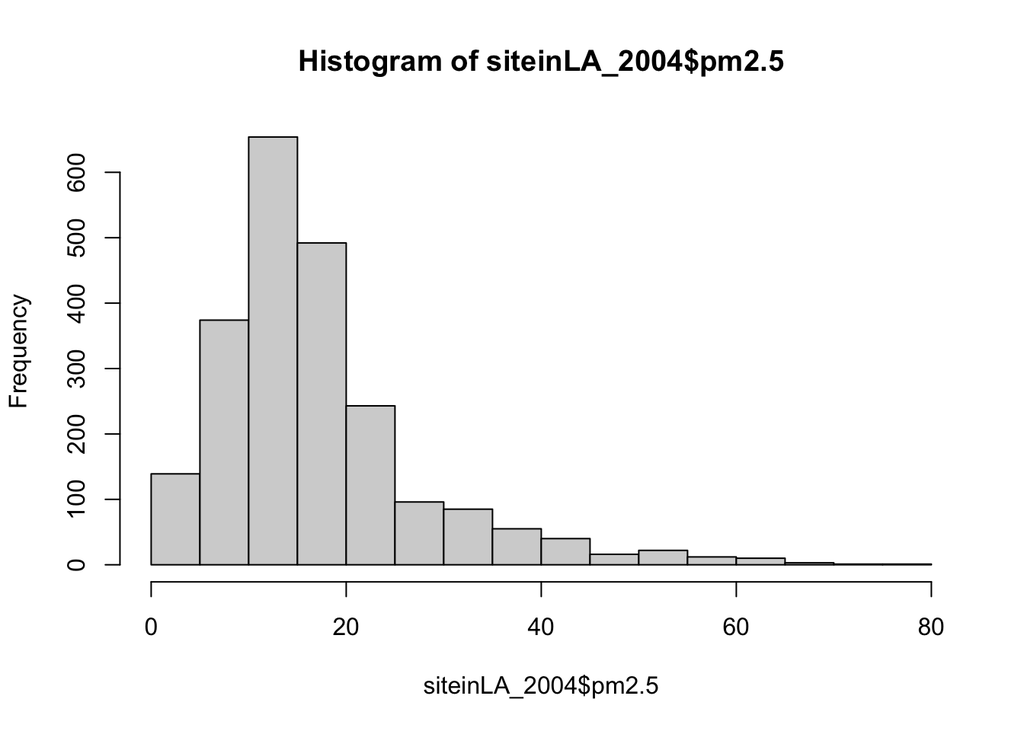

```r
hist(siteinLA_2004$pm2.5)
```

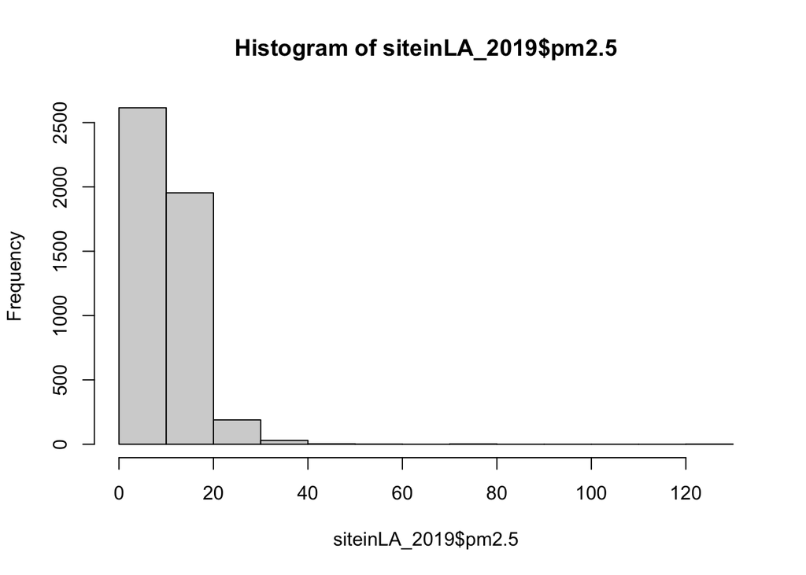

```r
hist(siteinLA_2019$pm2.5)
```

```r
county = total2 %>% select(pm2.5, county,year)
head(county)
```

```
##    pm2.5  county year
## 1:   8.9 Alameda 2004
## 2:  12.2 Alameda 2004
## 3:  16.5 Alameda 2004
## 4:  19.5 Alameda 2004
## 5:  11.5 Alameda 2004
## 6:  32.5 Alameda 2004
```

```r
str(county)
```

```
## Classes 'data.table' and 'data.frame':   72268 obs. of  3 variables:
##  $ pm2.5 : num  8.9 12.2 16.5 19.5 11.5 32.5 15.5 29.9 21 16.9 ...
##  $ county: chr  "Alameda" "Alameda" "Alameda" "Alameda" ...
##  $ year  : int  2004 2004 2004 2004 2004 2004 2004 2004 2004 2004 ...
##  - attr(*, ".internal.selfref")=<externalptr>
```

```r
countypm2.5=tapply(county$pm2.5,county[,c(3,2)],mean)
county_diff=data.frame(countypm2.5[1,]-countypm2.5[2,])
county_diff
```

```
##                 countypm2.5.1......countypm2.5.2...
## Alameda                                   3.7423180
## Butte                                     3.0774761
## Calaveras                                 2.1456106
## Colusa                                    3.4411493
## Contra Costa                              5.5849282
## Del Norte                                -1.6281308
## El Dorado                                 0.7617932
## Fresno                                    6.8169998
## Glenn                                            NA
## Humboldt                                  1.4636654
## Imperial                                  1.4647938
## Inyo                                     -0.1617892
## Kern                                      8.7061437
## Kings                                     7.5203520
## Lake                                      1.3266667
## Los Angeles                               6.9292891
## Madera                                           NA
## Marin                                    -0.2713095
## Mariposa                                  5.0366564
## Mendocino                                 1.2564704
## Merced                                    7.9093750
## Mono                                     -1.3109147
## Monterey                                  2.4031300
## Napa                                             NA
## Nevada                                   -0.5278902
## Orange                                    7.3210971
## Placer                                    7.7838118
## Plumas                                    1.7340807
## Riverside                                 9.9694865
## Sacramento                                6.3152180
## San Benito                               -0.3394496
## San Bernardino                            4.7111452
## San Diego                                 4.1699496
## San Francisco                             3.1152691
## San Joaquin                               4.8594947
## San Luis Obispo                           2.0262074
## San Mateo                                 3.8175339
## Santa Barbara                             1.6355333
## Santa Clara                               4.2326902
## Santa Cruz                                1.1305578
## Shasta                                    1.4220403
## Siskiyou                                 -2.4878248
## Solano                                    3.7772930
## Sonoma                                    3.4645552
## Stanislaus                                4.6523100
## Sutter                                    3.4332922
## Tehama                                           NA
## Trinity                                  -2.1779005
## Tulare                                    5.3604312
## Ventura                                   4.5231436
## Yolo                                      2.8138116
```